# UW 350: HW1

```r
  cor(energy$Cooling.Load,energy$Glazing.Area)
```

```
## [1] 0.207505
```

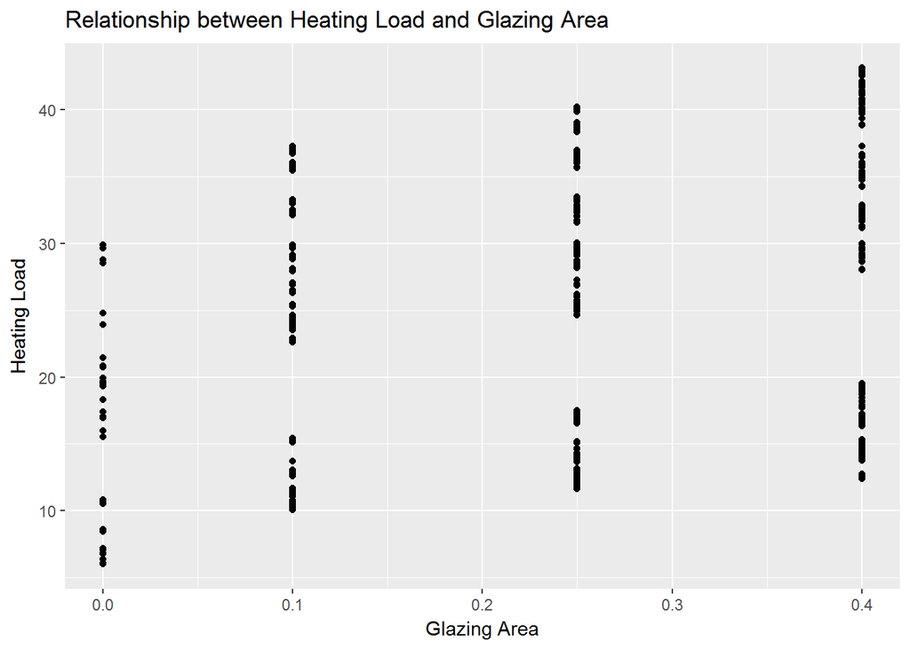

```r
  #Scatter and Violin plot of the Heating/Cooling Load and Glazing Area
  ggplot(energy, aes(y = Heating.Load, x = Glazing.Area))+ geom_point() + xlab("Glazing Area") + ylab("Heating Load") + ggtitle("Relationship between Heating Load and Glazing Area")
```

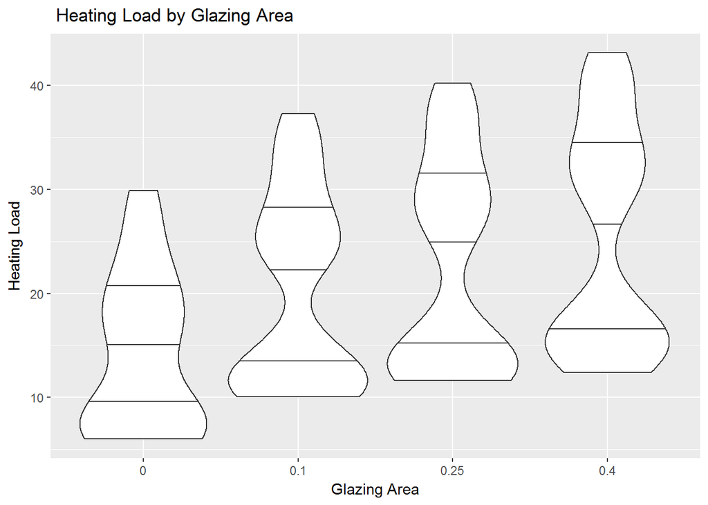

```r
  ggplot(energy, aes(x = factor(Glazing.Area), y = Heating.Load)) + geom_violin(trim = TRUE, draw_quantiles = c(0.25,0.5,0.75)) + xlab("Glazing Area") + ylab("Heating Load") + ggtitle(" Heating Load by Glazing Area")
```

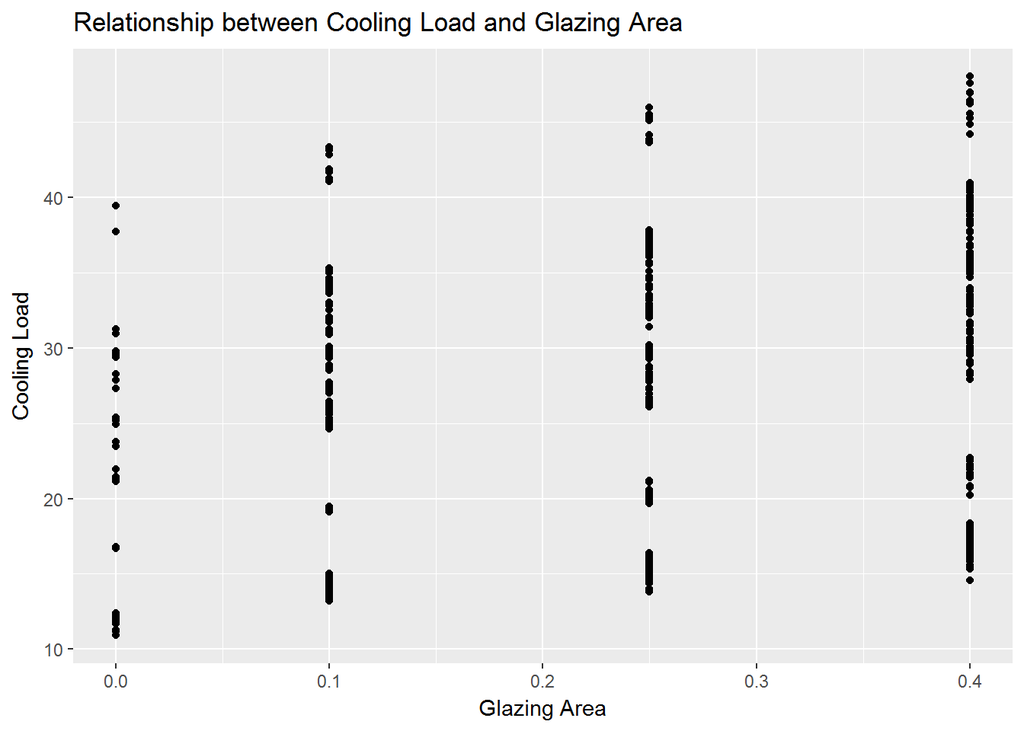

```r
  ggplot(energy, aes(y = Cooling.Load, x = Glazing.Area))+ geom_point() + xlab("Glazing Area") + ylab("Cooling Load") + ggtitle("Relationship between Cooling Load and Glazing Area")
```

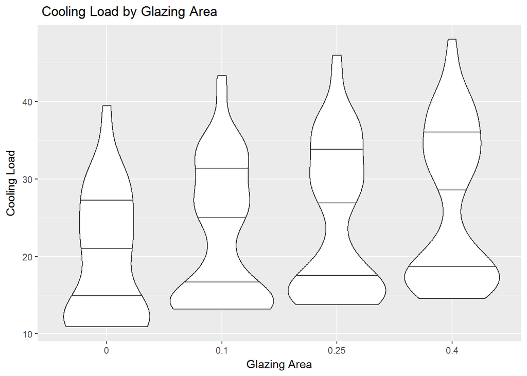

```r
  ggplot(energy, aes(x = factor(Glazing.Area), y = Cooling.Load)) + geom_violin(trim = TRUE, draw_quantiles = c(0.25,0.5,0.75)) + xlab("Glazing Area") + ylab("Cooling Load") + ggtitle(" Cooling Load by Glazing Area")
```

- Correlation between Heating Load and Glazing Area is : 0.270. Correlation coefficient is low implying not a strong correlation between Glazing Area and Heating Load.
- Correlation between Cooling Load and Glazing Area is : 0.208. Correlation coefficient is low implying not a strong correlation between Glazing Area and Heating Load.
- However, the violin plot shows that the distribution of Heating/Cooling moves towards higher values as the Glazing area changes from 0 units to 0.4 units.

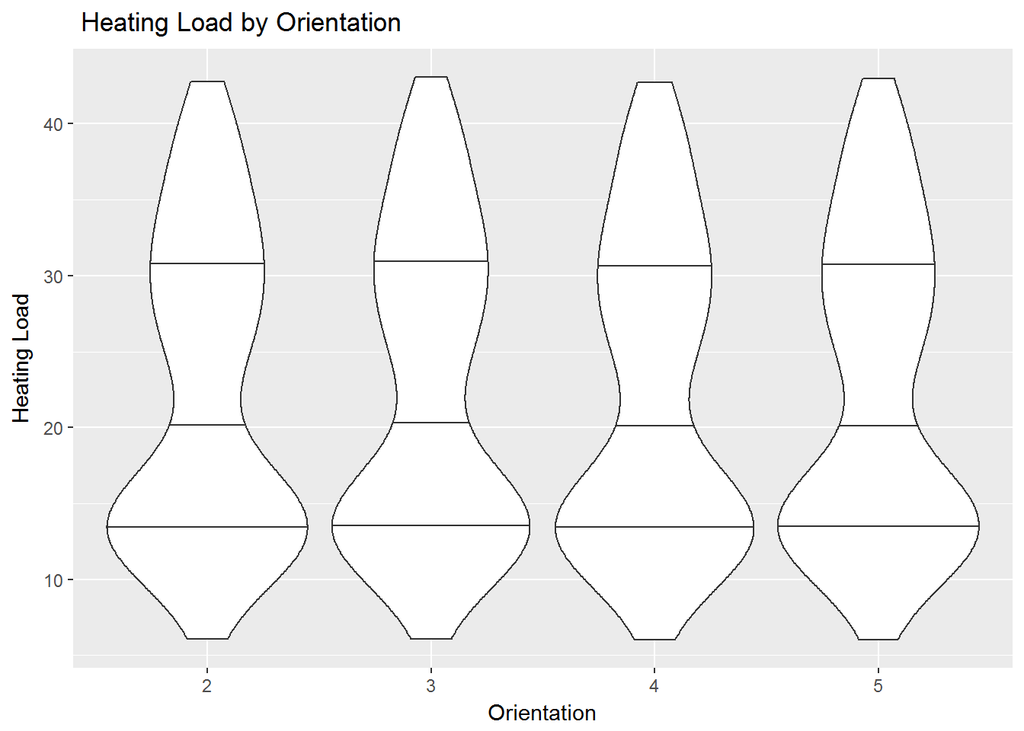

```r
  # Violin plot of the Heating/Cooling Load and Orientation
  ggplot(energy, aes(x = factor(Orientation), y = Heating.Load)) + geom_violin(trim = TRUE, draw_quantiles = c(0.25,0.5,0.75)) + xlab("Orientation") + ylab("Heating Load") + ggtitle(" Heating Load by Orientation")
```

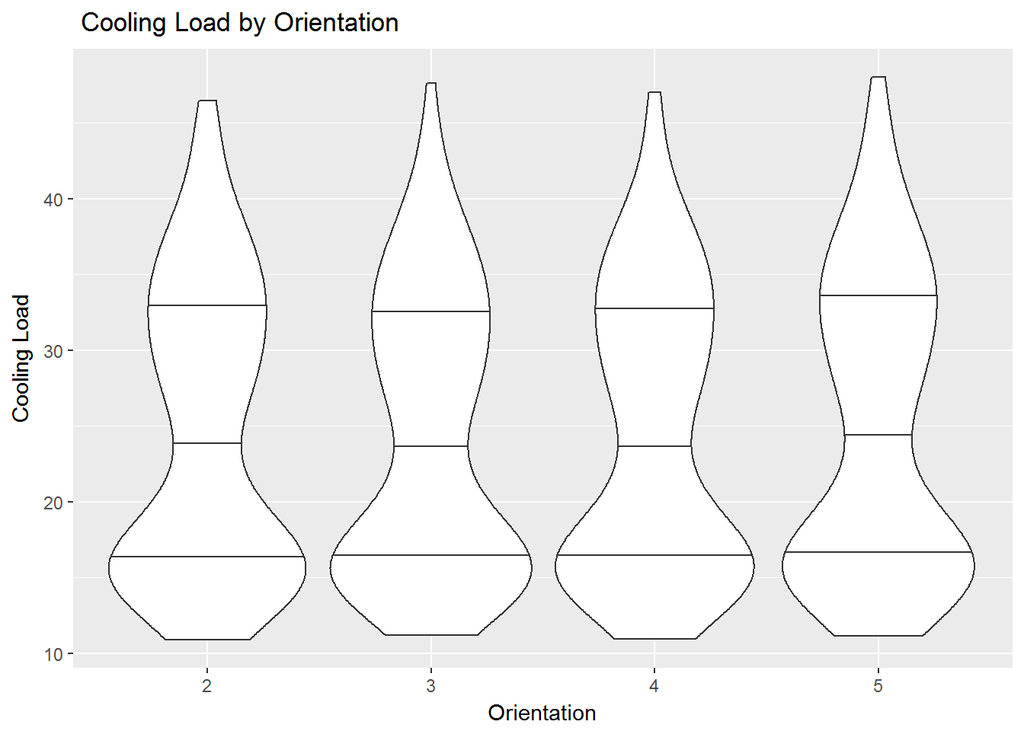

```r
  ggplot(energy, aes(x = factor(Orientation), y = Cooling.Load)) + geom_violin(trim = TRUE, draw_quantiles = c(0.25,0.5,0.75)) + xlab("Orientation") + ylab("Cooling Load") + ggtitle(" Cooling Load by Orientation")
```

- The violin plot shows that the distribution of Heating/Cooling distribution is same for all Orientations.